# BOO 2025 - Example Analysis

Script 2: Probe QC - Questions

Jurgen Zwerwer

2025-05-14

> In this script, you will perform probe-level quality control (QC), ensuring that the final data set contains only well-expressed, relevant genes.

# 1 Setup

## 1.1 Clean

As before, we perform several setup steps at the start of the script to ensure our work is reproducible and clear.

**Exercise 1: Download the R markdown template and clean your environment.**

**Hint**

Use the code dropdown menu in the top right corner of this document.

```r
#
ls()
```

```
## character(0)
```

## 1.2 Load packages

Here, we introduce a second package:

- `readxl` allows you to read in Excel files, such as the probe manifest

**Exercise 2: Load `tidyverse` and `readxl` into your R environment**

**Hint**

You may need to install packages before you load them for the first time with the `install.packages()` function.

```r
#
library(tidyverse)
library(readxl)
library(dplyr)
```

## 1.3 Set variables

As before, we set directories and commonly used variables at the start of the script to make it easier to adjust anything later.

**Exercise 3: Create the following objects:**

- `root_dir` - the root directory for your project
- `count_path` - the location of the count data
- `metadata_path` - the location of the metadata
- `manifest path` - the probe manifest for TempO-Seq probes
- `count_store` - where you want to save the count data after QC
- `cpm_store` - where you want to store the CPM data
- `metadata_store` - where you want to save the metadata
- `probedata_store` - where to store the updated manifest

```r
root_dir <- "~/Documents/BOO 2025 Code/Project/QC/"
count_path <- file.path(root_dir, "data", "countData.txt")
metadata_path <- file.path(root_dir, "data", "metaData.txt")
manifest_path <- file.path(root_dir, "data", "ProbeManifest.xlsx")

count_store <- file.path(root_dir, "results", "qc_counts.rds")
cpm_store <- file.path(root_dir, "results", "cpm_data.rds")
metadata_store <- file.path(root_dir, "results", "clean_metadata.rds")
probedata_store <- file.path(root_dir, "results", "updated_manifest.rds")
```

## 1.4 Load data

For the probe QC, we will use the count data, metadata, and probe manifest.

**Exercise 4: Load required data into the environment:**

**Hint**

The `read_xlsx()` function from the `readxl` package can be used to read in Excel files.

```r
Gene_count <- data.table::fread("~/Documents/BOO 2025 Code/Project/QC/Input/countData.txt", sep = "\t")
Gene_meta <- data.table::fread("~/Documents/BOO 2025 Code/Project/QC/Input/metaData.txt", sep = "\t")
probe_manifest <- read_excel("~/Documents/BOO 2025 Code/Project/QC/Input/ProbeManifest.xlsx")
```

# 2 Annotation

## 2.1 Motivation

In TempO-Seq, each gene is detected using a unique probe sequence. In order to ensure accuracy in our gene annotations and downstream analyses, we need to confirm that these probes align to the locations on the genome that we expect them to.

To do this, we used [NCBI BLAST (Basic Local Alignment Search Tool)](https://blast.ncbi.nlm.nih.gov/Blast.cgi), a tool that allows us to compare the probe sequences against a reference genome database. By uploading our probe sequences to BLAST, we could:

1. Verify that each probe still uniquely matches the gene it was designed for,
2. Check for any outdated or incorrect annotations, especially since the genome has been updated since the probes were designed, and
3. Update our manifest file (the reference file we use to link probe names to gene IDs in this script).

**Exercise 5: What problems could arise in your project if you did not update the probe annotations?**

Probes could be assigned to wrong genes, resulting in incorrect data.

## 2.2 Update

The manifest provided during this project contains updated information about the probes.

**Exercise 6: Describe the columns in the probe manifest**

probe_name_old: old name used for probes probe_ID: ID of probes probe_sequence: Nucleotide sequence of probes probe_coord: coordinates where the probe binds gene_symbol: symbol of gene entrez_id: NCBI Entrez Gene ID matching the gene symbol. ensembl_id: Ensembl gene identifier hgnc_id: HUGO Gene Nomenclature Committee gene identifier gene_symbol_old: old gene symbol entrez_id_old: entrex id used previously percentage_match: similarity between probe sequence and gene target, indicating probe specificity

```r
#
```

**Exercise 7: Check that we have annotation information for all of the probes in `countData`:**

```r
#
all(Gene_count$Probe %in% probe_manifest$probe_name_old)
```

```
## [1] TRUE
```

Sometimes, the probe sequence could no longer be aligned to a specific gene in the reference genome. In this instance, the `gene_symbol` column will be NA.

**Exercise 8: How many probes could not be aligned in the updated manifest? What should be do with these probes and why?**

Probably remove them as they don’t have a function.

```r
#
probe_manifest %>% filter(is.na(probe_manifest$gene_symbol))
```

| probe_name_old | probe_ID | probe_sequence | probe_coord | gene_symbol | entrez_id | ensembl_id | hgnc_id | gene_symbol_old | entrez_id_old | percentage_match |
| --- | --- | --- | --- | --- | --- | --- | --- | --- | --- | --- |
| ABCF2_92347 | 92347 | CGCACTCGTCCTCGCCCGCGTGAGTCCCCTCCGAGTCTCCACGCTCGTCA | 7:151226948-151226997:- | NA | NA | NA | NA | ABCF2 | NA | 100 |
| ABCF2_92349 | 92349 | TTACTAGTAAGAATGCCTGGGCCCTGCTCCATCCCTCTCAGGAATCTTCG | 7:151226537-151226586:- | NA | NA | NA | NA | ABCF2 | NA | 100 |
| AC007406.5_28160 | 28160 | TAGAGAAATAGCCAACAGAGTCTAGAGTACGTTTAACATCATCCCACAGG | 12:276978-277027:- | NA | NA | NA | NA | AC007406.5 | NA | 100 |
| AC073648.1_22102 | 22102 | ACAGTCAGGATCATGCCTTCTATACATGCAAAAAGGACCAAGAAAAACAT | 4:8949953-8950002:+ | NA | NA | NA | NA | AC073648.1 | NA | 100 |
| AC104389.4_33621 | 33621 | TCAAGTTTGCCTTGTCAAGGCTATTGGTCAAGGCAAGGCTGGCCAACCCA | 11:5254869-5254918:- | NA | NA | NA | NA | AC104389.4 | NA | 100 |
| ACOT1_33866 | 33866 | ATGACGACAGCAGCCGTGATGCCCTCAGGATGACTGAGCAAGTAGTTCAC | 14:73541670-73543151:+ | NA | NA | NA | NA | ACOT1 | NA | NA |
| ACTBP9_4576 | 4576 | GGTCTCCGCGGTCTAGAACCCATTTTAGCTGGTAGCAACAATTCAGCCAG | NA | NA | NA | NA | NA | ACTBP9 | NA | 100 |
| ACTBP9_82 | 82 | ATGGAGCTGCCAATCCACATGGAGTATTTGCGCTCAGAAGGAGCAATGAT | 18:62442987-62443036:+ | NA | NA | NA | NA | ACTBP9 | NA | 100 |
| ACY1_22695 | 22695 | GGACTTAGGGTCCAGCGAGGTCGCCTGCGAGGTCGCAGGCTCAGGACCGC | 3:51983481-51983530:+ | NA | NA | NA | NA | ACY1 | NA | 100 |
| ADAL_24597 | 24597 | AAGAAAGGTCAGCCGCAAGCGAACTTAGCACTGGCTACACCCTCCTCAAT | 15:43330661-43330710:+ | NA | NA | NA | NA | ADAL | 161823 | 100 |

[output cut: 593 more lines]

**Exercise 9: How many probes have had their annotation updated by the manifest?**

**Hint**

The annotation is updated if the old and updated `gene_symbol` do not match.

```r
#
probe_manifest %>% filter(gene_symbol != gene_symbol_old)
```

| probe_name_old | probe_ID | probe_sequence | probe_coord | gene_symbol | entrez_id | ensembl_id | hgnc_id | gene_symbol_old | entrez_id_old | percentage_match |
| --- | --- | --- | --- | --- | --- | --- | --- | --- | --- | --- |
| AC002116.2_11937 | 11937 | AACTCCATTTCCAGGTGTGTGGCCAACCCCTGTCCCCTCTCCTATGTGAC | 19:36016872-36016921:+ | LOC101927572 | 101927572 | NA | NA | AC002116.2 | NA | 100 |
| AC007342.3_17969 | 17969 | ATCTTTGTTGTTCACATTTCTGGAACTTTTACCTGACTCATCATCATTAT | 16:53370259-53370732:- | MPHOSPH10P1 | 643802 | ENSG00000291103 | 55687 | AC007342.3 | NA | 100 |
| AC007666.1_28481 | 28481 | GCTAAACCTGGCATGAGAAGACAATGCTTCCCTCCGTGTTAGGGCTGCCT | 22:17588691-17588740:- | LOC101929372 | 101929372 | NA | NA | AC007666.1 | NA | 100 |
| AC008397.1_89032 | 89032 | GGTTCCCCTGAACTGTGGGTGCTGTGGGCGAAGGGAGAAGAAATCAGAGA | 19:18252377-18252426:- | CIST1 | 729966 | ENSG00000284797 | 55823 | AC008397.1 | NA | 100 |
| AC008687.4_88136 | 88136 | ATAATGCGGTGGGAAAAGTAGCTGCTGGTGAGATGGCAGTTGGGCCTGGA | 19:49020408-49020457:- | SAXO3 | 101059948 | ENSG00000268655 | 56771 | AC008687.4 | NA | 100 |
| AC010255.3_24596 | 24596 | CTGGCAGGAAGGTACGCCCACAAACATTACAGGGAACCAACTGGCTGTGG | 5:122182544-122182593:+ | ZNF475 | 100505841 | ENSG00000250803 | 53564 | AC010255.3 | NA | 100 |
| AC010442.1_5295 | 5295 | GGCTGCCGTGAGTGAGGTGTTCTCACTCTGGTTCCGTGTTTGTGTTTAGC | 5:471049-471098:- | SLC9A3 | 6550 | ENSG00000066230 | 11073 | AC010442.1 | NA | 100 |
| AC011043.1_14126 | 14126 | GGGAATACAAGGCCTCCACTCTCACATGGCTTGATTGACTGATGAACTGA | GL000195.1:44806-44855:- | LOC389831 | 389831 | NA | NA | AC011043.1 | NA | 100 |
| AC011525.2_20202 | 20202 | CAGCTCTCTGAAGAATACTTCTTCCACCTGATGGTCCACCTTCCAGAATG | 19:31592482-31592531:+ | LINC03103 | 100507527 | ENSG00000267465 | 48330 | AC011525.2 | NA | 100 |
| AC011525.2_27956 | 27956 | TCATGTCCACTTCCTTGAGAAACAATTTTGCCTTTGTAAAGTCTGCACCA | 19:31592917-31592966:+ | LINC03103 | 100507527 | ENSG00000267465 | 48330 | AC011525.2 | NA | 100 |

[output cut: 598 more lines]

**Exercise 10: Create `flag_realignment`, a new column in `probeManifest` which describes whether a probe should be removed, renamed, or kept unchanged:**

**Hint**

Try using `case_when()` inside the `mutate()` function.

```r
probe_manifest2 <- probe_manifest %>%
  mutate(flag_realignment = case_when(
    is.na(gene_symbol) ~ "remove",
    gene_symbol != gene_symbol_old ~ "rename",
    TRUE ~ "keep"
  ))
```

If probes could not be aligned, they should be removed from the `countData`.

**Exercise 11: Subset `countData` to keep only the probes with correct annotations.**

```r
Gene_count2 <- as.data.frame(Gene_count)
rownames(Gene_count2) <- Gene_count2$Probe
Gene_count2$Probe <- NULL
kept_probes <- (probe_manifest2 %>%
  filter(flag_realignment != "remove"))$probe_name_old

Gene_count2 <- Gene_count2[kept_probes, ]
```

As well as removing probes that could not be annotated, we also want to update the names of probes where the gene name has changed.

**Exercise 12: Create `probe_name`, a new column in `probeManifest` that contains the updated probe names, and adjust the `countData` row names accordingly:**

**Hint**

The new probe name should be a combination of `gene_symbol` and `probe_ID`.

```r
probe_manifest2$probe_name <- paste0(probe_manifest2$gene_symbol, "_", probe_manifest2$probe_ID)

# Create a named vector: names are old names, values are new names
name_map <- setNames(probe_manifest2$probe_name, probe_manifest2$probe_name_old)

# Replace rownames in Gene_count
rownames(Gene_count2) <- name_map[rownames(Gene_count2)]
```

It is good practice to check the dimensions of objects when making such adjustments using the `dim()` function.

**Exercise 13: Check the dimensions of the objects in your environments to ensure nothing went wrong:**

```r
#
dim(Gene_count2)
```

```
## [1] 21930    66
```

# 3 Normalization

## 3.1 CPM

Counts Per Million (CPM) normalization is a method that accounts for differences in sequencing depth between samples. It scales raw read counts (as in `countData`) so that the total counts per sample sum to one million. This allows for comparison of gene expression levels across samples.

**Exercise 14: Calculate CPM values for our data and store them in a `cpmData` object:**

```r
cpmData <- apply(Gene_count2, 2, function(x) (x / sum(x)) * 1e6)
```

# 4 Probe relevance

## 4.1 Highly expressed genes

By inspecting the most highly expressed genes in a dataset, you can build confidence in the data and get an idea of processes with particular relevance to your project.

**Exercise 15: Add the columns `total_cpm` and `average_cpm` to the probe manifest and describe a few of the most highly expressed genes. Do they make biological sense?**

**Hint**

You can look up gene functions using [NCBI](https://www.ncbi.nlm.nih.gov/gene/) or [GeneCards](https://www.genecards.org/).

```r
# Step 1: Calculate total and average CPM per probe
cpm_totals <- rowSums(cpmData)
cpm_means <- rowMeans(cpmData)

# Step 2: Add to probe manifest
probe_manifest2 <- probe_manifest2 %>%
  mutate(
    total_cpm = cpm_totals[probe_name],
    average_cpm = cpm_means[probe_name]
  )

probe_manifest2 %>%
  arrange(desc(average_cpm)) %>%
  select(probe_name, gene_symbol, average_cpm) %>%
  head(10)
```

| probe_name | gene_symbol | average_cpm |
| --- | --- | --- |
| HP_3085 | HP | 9301.495 |
| HSPB1_92509 | HSPB1 | 5977.752 |
| APOA1_87403 | APOA1 | 5173.005 |
| ALB_217 | ALB | 4223.090 |
| APOC3_15165 | APOC3 | 4029.877 |
| ORM1_4833 | ORM1 | 3762.441 |
| CALD1_18940 | CALD1 | 3288.933 |
| BAAT_614 | BAAT | 3228.818 |
| WDR1_15416 | WDR1 | 3162.930 |
| FTH1_93388 | FTH1 | 2936.304 |

## 4.2 Lowly expressed genes

Although these highly expressed genes are interesting and informative, there are also many lowly expressed genes in our data. When genes have very low expression levels, small absolute changes can be represented by very high fold changes. We want to remove these lowly expressed and noisy genes from our data with the relevance filter.

**Exercise 16: Visualize the distribution of log2(average CPM + 1) across your data. Can you identify these lowly expressed genes?**

**Hint**

Genes with an average CPM below 1 are generally considered to be lowly expressed.

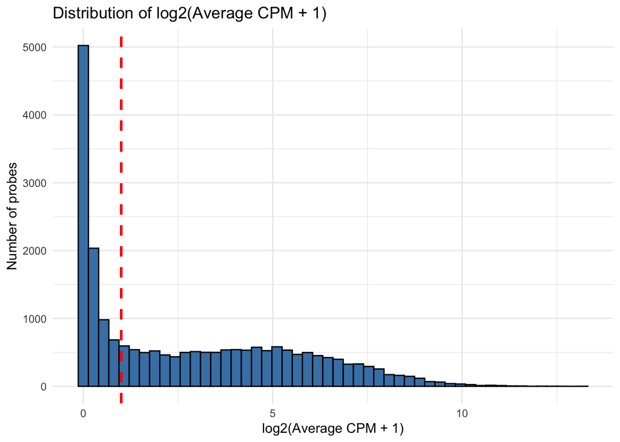

```r
library(ggplot2)

# Step 1: Calculate average CPM per gene
avg_cpm <- rowMeans(cpmData)

# Step 2: Log2-transform the average CPM (+1 to avoid log(0))
log2_avg_cpm <- log2(avg_cpm + 1)

# Step 3: Convert to data frame for ggplot
df_log2_cpm <- data.frame(log2_avg_cpm = log2_avg_cpm)

# Step 4: Plot using ggplot2
ggplot(df_log2_cpm, aes(x = log2_avg_cpm)) +
  geom_histogram(bins = 50, fill = "steelblue", color = "black") +
  geom_vline(xintercept = log2(1 + 1), color = "red", linetype = "dashed", linewidth = 1) +
  labs(title = "Distribution of log2(Average CPM + 1)",
       x = "log2(Average CPM + 1)",
       y = "Number of probes") +
  theme_minimal()
```

**Exercise 17: Why did you use a log2 transformation here and why was it necessary to add 1 to the CPM values?**

log2(CPM + 1) is applied to make expression values more interpretable and it avoids log2(0) as this gives -infinity

**Exercise 18: How many probes have no expression measured in any of the samples?**

```r
# Identify probes with CPM = 0 in all samples
zero_expression <- rowSums(cpmData) == 0

# Count how many probes have no expression
sum(zero_expression)
```

```
## [1] 410
```

## 4.3 Relevance

We want to keep probes in our data if they are relevant for any of our experiments. Here, we define relevance as having a CPM above 1 for at least two thirds of the replicates.

**Exercise 19: How many experimental conditions do we have in this data and how many replicates are there for each?**

7 different concentrations of chloroacetamide and TMA exposed to PHHs, there are 3 replicates for each experimental condition. There are also controls.

```r
# Create a column that defines the experimental condition
Gene_meta$experimental_condition <- paste(Gene_meta$compound_ID, Gene_meta$conc_amt, sep = "_")

# Number of unique experimental conditions (excluding controls)
n_conditions <- length(unique(Gene_meta$experimental_condition[Gene_meta$sample_type != "Control"]))

# Count replicates per condition
replicates_per_condition <- table(Gene_meta$experimental_condition)

# Show result
n_conditions
```

```
## [1] 14
```

```r
replicates_per_condition
```

```
##
## CS1128_0.03  CS1128_0.3    CS1128_1   CS1128_10  CS1128_180  CS1128_3.1
##           3           3           3           3           3           3
##   CS1128_32 CS1140_0.03  CS1140_0.3    CS1140_1   CS1140_10  CS1140_180
##           3           3           3           3           3           3
##  CS1140_3.1   CS1140_32 DMSOHigh_NA  DMSOLow_NA
##           3           3          12          12
```

**Exercise 20: Loop through these experimental conditions, calculating for each the percentage of replicates where each probe is above the 1 CPM threshold:**

**Hint**

First create a vector of the experimental conditions to use in a `for()` loop.

```r
# Step 1: Create experimental condition column
Gene_meta$experimental_condition <- paste(Gene_meta$compound_ID, Gene_meta$conc_amt, sep = "_")

# Step 2: Define conditions to loop over (excluding controls)
conditions <- unique(Gene_meta$experimental_condition[Gene_meta$sample_type != "Control"])

# Step 3: Initialize output data frame
percent_above_1cpm <- data.frame(row.names = rownames(cpmData))

# Step 4: Loop over conditions
for (cond in conditions) {
  sample_ids <- Gene_meta$sample_ID[Gene_meta$experimental_condition == cond]
  sub_cpm <- cpmData[, sample_ids, drop = FALSE]
  percent_expressed <- rowMeans(sub_cpm > 1) * 100
  percent_above_1cpm[[cond]] <- percent_expressed
}
```

**Exercise 21: Add a column `n_relevant` to the relevance filter output which describes for how many experiments each probe is relevant. Merge the output with the probe manifest:**

**Hint**

The `rowSums()` function may come in handy :)

```r
# Count how many conditions each probe is "relevant" in (≥50% of replicates)
relevance_filter <- percent_above_1cpm >= 50  # logical matrix
n_relevant <- rowSums(relevance_filter)       # count TRUEs per probe

# Add to data frame
relevance_filter_output <- percent_above_1cpm
relevance_filter_output$n_relevant <- n_relevant
relevance_filter_output$probe_name <- rownames(relevance_filter_output)

# Merge with probe manifest
merged_output <- merge(probe_manifest2, relevance_filter_output, by = "probe_name")
```

## 4.4 Flag

We want to flag the lowly expressed probes in the manifest and remove them from our `countData`. These noisy, unreliable probes should not be included in our downstream analysis.

**Exercise 22: Flag any probes that do not pass the relevance filter for at least one experimental condition and remove them from `countData`:**

```r
# Add relevance flag: "remove" if n_relevant == 0, else "keep"
probe_manifest2$relevance_flag <- ifelse(merged_output$n_relevant[match(probe_manifest2$probe_name, merged_output$probe_name)] == 0,
                                         "remove", "keep")

# Keep only the probes that passed the relevance filter
kept_probes <- probe_manifest2$probe_name[probe_manifest2$relevance_flag != "remove"]

# Subset Gene_count and cpmData
Gene_count <- Gene_count[rownames(Gene_count) %in% kept_probes, ]
cpmData <- cpmData[rownames(cpmData) %in% kept_probes, ]
```

**Exercise 23: Visualize and interpret the distribution of `n_relevant`:**

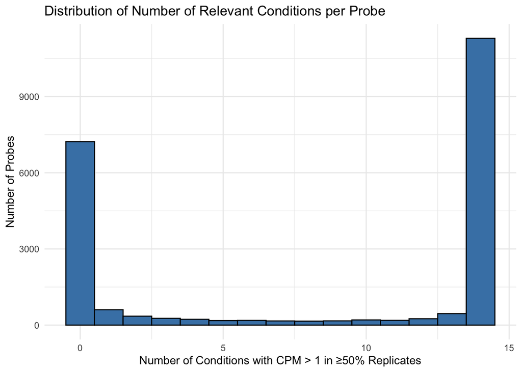

```r
library(ggplot2)
# Create the plot
ggplot(merged_output, aes(x = n_relevant)) +
  geom_histogram(binwidth = 1, fill = "steelblue", color = "black") +
  labs(
    title = "Distribution of Number of Relevant Conditions per Probe",
    x = "Number of Conditions with CPM > 1 in ≥50% Replicates",
    y = "Number of Probes"
  ) +
  theme_minimal()
```

**Exercise 24: Check the distribution of log2(CPM + 1) values coloured by the relevant filter flag. Has the peak of lowly expressed genes been reduced?**

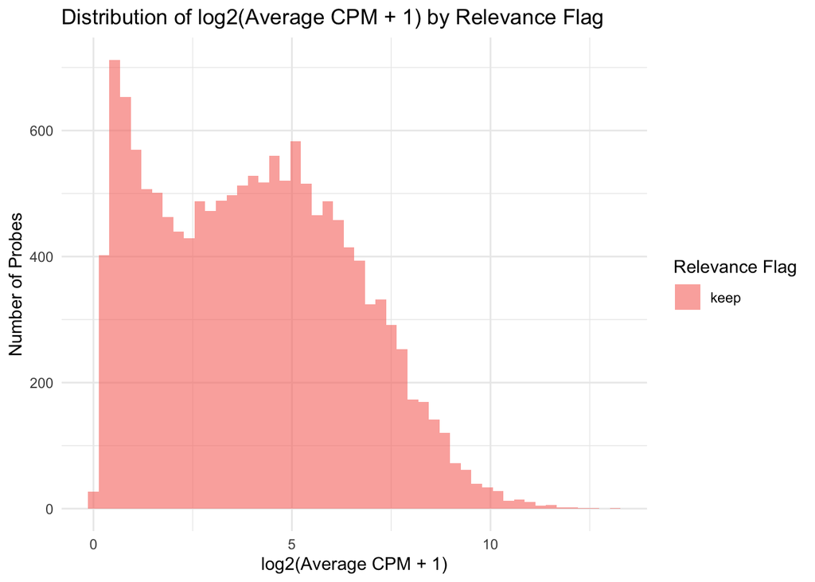

```r
# Step 1: Calculate average log2(CPM + 1) per probe
avg_log2_cpm <- rowMeans(log2(cpmData + 1))

# Step 2: Create a data frame with relevance flag
log2_cpm_df <- data.frame(
  probe_name = rownames(cpmData),
  avg_log2_cpm = avg_log2_cpm,
  relevance_flag = probe_manifest2$relevance_flag[match(rownames(cpmData), probe_manifest2$probe_name)]
)

# Step 3: Plot distribution
ggplot(log2_cpm_df, aes(x = avg_log2_cpm, fill = relevance_flag)) +
  geom_histogram(position = "identity", bins = 50, alpha = 0.6) +
  labs(
    title = "Distribution of log2(Average CPM + 1) by Relevance Flag",
    x = "log2(Average CPM + 1)",
    y = "Number of Probes",
    fill = "Relevance Flag"
  ) +
  theme_minimal()
```

The peak is around log2(1) to log2(2), indicating average CPM values above 0, normally dominated by lowly expressed genes. However, this histogram only shows probes flagged to keep the relevant probes, as there is no huge spike at 0, most of the low-expression probes have been successfully removed. ***

# 5 Gene-level data

## 5.1 Sum

Multiple probes from TempO-Seq may interrogate the same gene. Since all of our downstream analyses will be performed at the gene level, we sum probes interrogating the same gene to create gene-level data.

**Exercise 25: Sum the counts of probes interrogating the same gene and store the gene-level data:**

**Hint**

Use the `separate` command on the probe names to create a gene name variable easily in the `countData`.

```r
Gene_count2 <- Gene_count2 %>%
  # Step 1: Create a column of row (probe) names
  rownames_to_column(var = "probe_name") %>%

  # Step 2: Extract the gene symbol from the probe name (before the underscore)
  separate(probe_name, into = c("gene_symbol", NA), sep = "_") %>%

  # Step 3: Group the count data by gene symbol
  group_by(gene_symbol) %>%

  # Step 4: Sum the counts across all probes per gene
  summarise(across(where(is.numeric), sum), .groups = "drop") %>%

  # Step 5: Set gene symbols as row names
  column_to_rownames(var = "gene_symbol")
```

**Exercise 26: Re-apply CPM normalization on this gene level data**

```r
cpmData <- apply(Gene_count2, 2, function(x) (x / sum(x)) * 1e6)
```

# 6 Advanced questions

If you would like a bit more of a challenge, here are a few extra questions relating to the two probe QC steps above. However, you can also skip these, save your data, and move on to the sample QC.

## 6.1 Probe realignment

Some of the probes that could not be aligned to the most recent reference genome interrogate genes that are still present in the data.

**Exercise 27: For genes interrogated by more than 5 probes where at least one of these was removed during realignment, investigate whether the removed probe measured more or fewer counts than the ones remaining in the data.**

**Hint**

In order to answer these questions at the end of the script (after all the filters), you may want to save a `countData_original` object on loading count data into the environment.

```r
#
```

## 6.2 Relevance filter

Some probes that were kept in the data had very low average expression levels, but were deemed relevant for one of the experimental conditions.

**Exercise 28: Take a look at the most extreme examples of such probes. What conditions are responsible for them being kept in the data?**

```r
#
```

# 7 Save

**Exercise 29: Save the following objects:**

- `probeManifest` containing information on probes, their expression levels, and the results of the different filters
- `countData` containing the filtered count data for probes that should be used in downstream analysis
- `cpmData` containing the CPM normalized counts for relevant, well-expressed probes

```r
save(probe_manifest2, file=file.path(root_dir, "Output/probeData_QC.RData"))
save(Gene_count2, file=file.path(root_dir, "Output/countData_QC.RData"))
save(Gene_meta, file=file.path(root_dir, "Output/metaData_QC.RData"))
```

**Exercise 31: Knit this script to produce either a `PDF` or `HTML`file and push it to your GitHub repository.**

That is the end of the Probe QC. Example answers will be available from the `BOO_template` GitHub on Tuesday.

Next, please move on to the probe QC using `03_SampleQC_Outline.Rmd`.